# Clustering

Arun Chavan

Started: 2021-03-11  
Last edited: 2021-03-15 22:49:49

# 1 Background

Here we perform clustering of the amphioxus data based on parameters that we detemined according to tests in `05a_clustering_test-parameters.Rmd`. We will use:

1. All genes
2. SCTransform normalization
3. Leiden clustering

# 2 Setup

```r
# general packages
library(tidyverse)
library(here)
library(glue)

# plotting
library(ggthemes)
library(patchwork)
library(cowplot)
library(ggrepel)

# single cell
library(Seurat)
library(sctransform)
library(uwot)
```

```r
# here setup
basedir <- here("species/bflo/10x/run_01/refseq__GCF_000003815.2_Bfl_VNyyK")
genomedir <- here("species/bflo/genome/refseq__GCF_000003815.2_Bfl_VNyyK")
```

```r
# ggplot setup
source(here(basedir, "code/utilities_ggplot.R"))
```

```
Updated default font for geoms `text` and `text_repel` to: Source Sans Pro
```

```r
# knitr setup
knitr::opts_chunk$set(dpi = 300)
```

```r
# custom functions
source(here(basedir, "code/utilities_clustering.R"))
```

```
Loaded helper function `merge_clusters()`, which internally runs:
    1. merge_small_clusters()
    2. merge_similar_clusters()
    3. rename_clusters_by_size()
```

# 3 Data

```r
bf <- read_rds(here(basedir, "data/04_qc/bflo_seurat_qc-filtered.rds"))
```

# 4 Gene info

```r
gene.info <- read_tsv(here(genomedir, "gene-info/gene-info_from-gtf.tsv"))

# extract gene lists (replace _ with - for compatibility with how Seurat stores gene names)
genes.rrna <- gene.info %>% filter(gbkey == "rRNA")                       %>% .$gene_id %>% unique() %>% gsub(pattern = "_", replacement = "-")
genes.mt   <- gene.info %>% filter(seqname == "NC_000834.1")              %>% .$gene_id %>% unique() %>% gsub(pattern = "_", replacement = "-")
genes.good <- gene.info %>% filter(!gene_id %in% c(genes.rrna, genes.mt)) %>% .$gene_id %>% unique() %>% gsub(pattern = "_", replacement = "-")
```

Note: two genes are both mitochondrial and rRNA genes, thus percent reads will not add to 100%

# 5 Normalization

## 5.1 CPT normalization

Regular CPT normalization for finding marker genes and for visualization.

```r
DefaultAssay(bf) <- "RNA"

bf <- NormalizeData(bf, verbose = F) %>%
  FindVariableFeatures(verbose = F, selection.method = "vst", nfeatures = 2000) %>%
  ScaleData(verbose = F)
```

## 5.2 SCT normalization

```r
bf <- SCTransform(bf,
                  vars.to.regress = "percent.mt",
                  conserve.memory = TRUE,
                  verbose = FALSE)
```

# 6 Clustering

```r
bf <- RunPCA(bf, verbose = FALSE, assay = "SCT", npcs = 200)
bf <- RunUMAP(bf, assay = "SCT", dims = 1:200, min.dist = 0.1,
              umap.method = "umap-learn", metric = "cosine", verbose = FALSE)

bf <- FindNeighbors(bf, dims = 1:200, k.param = 20, nn.method = "annoy", annoy.metric = "cosine", verbose = FALSE)
```

```r
bf <- FindClusters(bf, resolution = 10, algorithm = 4, verbose = FALSE)
```

```r
bf <- merge_clusters(bf, idents.to.merge = "SCT_snn_res.10", idents.merged.name = "cluster", min.cells = 20)
```

```
Merging small clusters ...
Merged cluster 79 into cluster 14 (correlation: 0.86).
Merged cluster 78 into cluster 5 (correlation: 0.88).
Merged cluster 77 into cluster 20 (correlation: 0.86).
Merged cluster 76 into cluster 53 (correlation: 0.93).
Merged cluster 75 into cluster 11 (correlation: 0.72).
Merged 5 cluster(s) with 20 or fewer cells into their respective nearest neighbours. Now there are 74 clusters.
Renamed 74 clusters by size.
Finished. Elapsed time: 2.84 secs.
Merging similar clusters ...
Merged clusters 30 and 36 (DE genes: 1; correlation: 0.98).
Merged clusters 2 and 9 (DE genes: 1; correlation: 0.97).
Merged clusters 15 and 18 (DE genes: 2; correlation: 0.97).
Merged clusters 14 and 16 (DE genes: 15; correlation: 0.96).
Merged clusters 3 and 11 (DE genes: 11; correlation: 0.96).
Merged clusters 32 and 60 (DE genes: 11; correlation: 0.96).
Merged clusters 10 and 42 (DE genes: 15; correlation: 0.95).
Merged clusters 47 and 70 (DE genes: 2; correlation: 0.95).
Merged clusters 6 and 34 (DE genes: 14; correlation: 0.95).
Merged clusters 17 and 26 (DE genes: 17; correlation: 0.95).
Merged clusters 37 and 54 (DE genes: 5; correlation: 0.95).
Merged clusters 49 and 55 (DE genes: 10; correlation: 0.94).
Merged clusters 24 and 53 (DE genes: 14; correlation: 0.94).
Merged clusters 1 and 39 (DE genes: 13; correlation: 0.93).
Merged clusters 20 and 67 (DE genes: 18; correlation: 0.91).
Merged clusters 21 and 27 (DE genes: 2; correlation: 0.91).
Merged clusters 35 and 61 (DE genes: 12; correlation: 0.91).
Merged clusters 45 and 46 (DE genes: 15; correlation: 0.88).
Merged clusters 4 and 64 (DE genes: 13; correlation: 0.88).
Merged clusters 7 and 51 (DE genes: 15; correlation: 0.87).
Merged clusters 52 and 72 (DE genes: 18; correlation: 0.8).
Merged clusters 44 and 68 (DE genes: 19; correlation: 0.65).
Merged clusters 65 and 74 (DE genes: 17; correlation: 0.64).
Merged clusters 15.18 and 30.36 (DE genes: 3; correlation: 0.98).
Merged clusters 2.9 and 47.70 (DE genes: 4; correlation: 0.96).
Merged clusters 14.16 and 3.11 (DE genes: 19; correlation: 0.96).
Merged clusters 21.27 and 32.60 (DE genes: 17; correlation: 0.95).
Merged clusters 65.74 and 71 (DE genes: 17; correlation: 0.64).
Merged clusters 14.16.3.11 and 15.18.30.36 (DE genes: 12; correlation: 0.98).
Merged clusters 21.27.32.60 and 58 (DE genes: 5; correlation: 0.91).
Merged clusters 14.16.3.11.15.18.30.36 and 49.55 (DE genes: 8; correlation: 0.97).
Merged clusters 14.16.3.11.15.18.30.36.49.55 and 37.54 (DE genes: 7; correlation: 0.96).
Finished merging nearest-neighbour clusters with fewer than 20 DE genes with a fold difference of 2.
Renamed 42 clusters by size.
Finished. Elapsed time: 19.06 mins.
```

# 7 Plots

## 7.1 UMAP

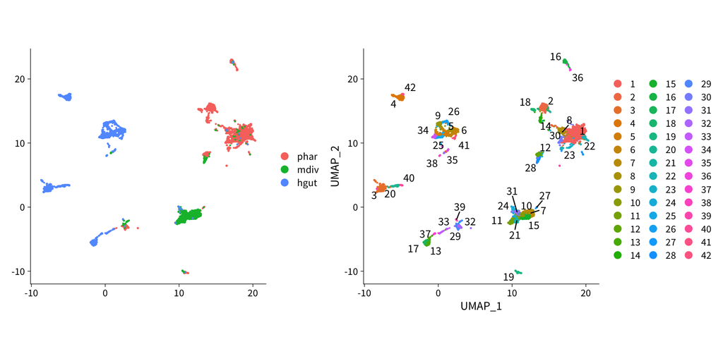

```r
umap_clust <- DimPlot(bf, label = TRUE, repel = TRUE) +
  theme_half_open_nogrid() +
  theme(aspect.ratio = 1)
umap_tissue <- DimPlot(bf, group.by = "orig.ident") +
  theme_half_open_nogrid() +
  theme(aspect.ratio = 1,
        title = element_blank())

ggsave(here(basedir, "results/05b_clustering/umap_by-clusters_allgenes_sct_leiden.pdf"),
       umap_clust, width = 5.5, height = 4.5, units = "in", device = cairo_pdf)
ggsave(here(basedir, "results/05b_clustering/umap_by-tissue.pdf"),
       umap_tissue, width = 5.5, height = 4.5, units = "in", device = cairo_pdf)

umap_tissue + umap_clust
```

## 7.2 PCA

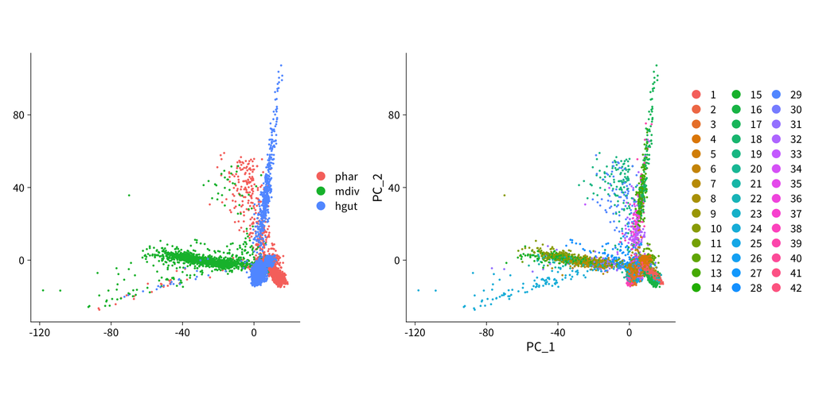

```r
pca_clust <- DimPlot(bf, reduction = "pca") +
  theme_half_open_nogrid() +
  theme(aspect.ratio = 1)
pca_tissue <- DimPlot(bf, group.by = "orig.ident", reduction = "pca") +
  theme_half_open_nogrid() +
  theme(aspect.ratio = 1,
        title = element_blank())

ggsave(here(basedir, "results/05b_clustering/pca_by-clusters_allgenes_sct_leiden.pdf"),
       pca_clust, width = 5.5, height = 4.5, units = "in", device = cairo_pdf)
ggsave(here(basedir, "results/05b_clustering/pca_by-tissue.pdf"),
       pca_tissue, width = 5.5, height = 4.5, units = "in", device = cairo_pdf)

pca_tissue + pca_clust
```

## 7.3 Number of cells

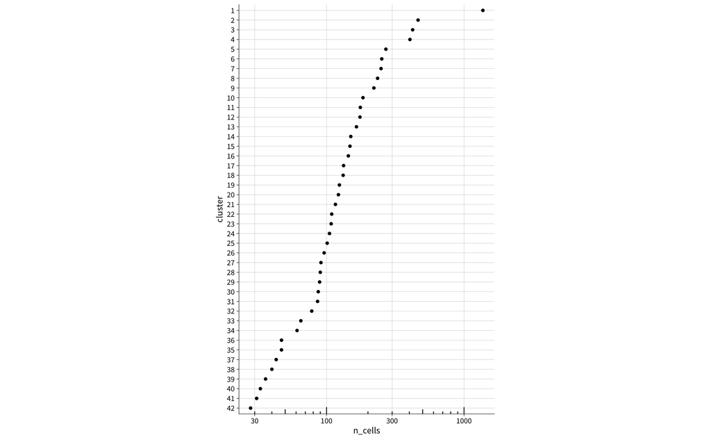

```r
ncells_by_cluster <- bf@meta.data %>%
  group_by(cluster) %>%
  tally() %>%
  arrange(n) %>%
  mutate(cluster = fct_inorder(cluster)) %>%
  ggplot(aes(n, cluster)) +
  geom_point() +
  scale_x_log10() +
  labs(x = "n_cells") +
  annotation_logticks(sides = "b") +
  theme_half_open_grid() +
  theme(aspect.ratio = 1.6)

ggsave(here(basedir, "results/05b_clustering/ncells_by_cluster.pdf"),
       ncells_by_cluster, width = 4, height = 6.5, units = "in", device = cairo_pdf)

ncells_by_cluster
```

## 7.4 Tissue contribution

What fraction of cells in each cluster come from which tissue?

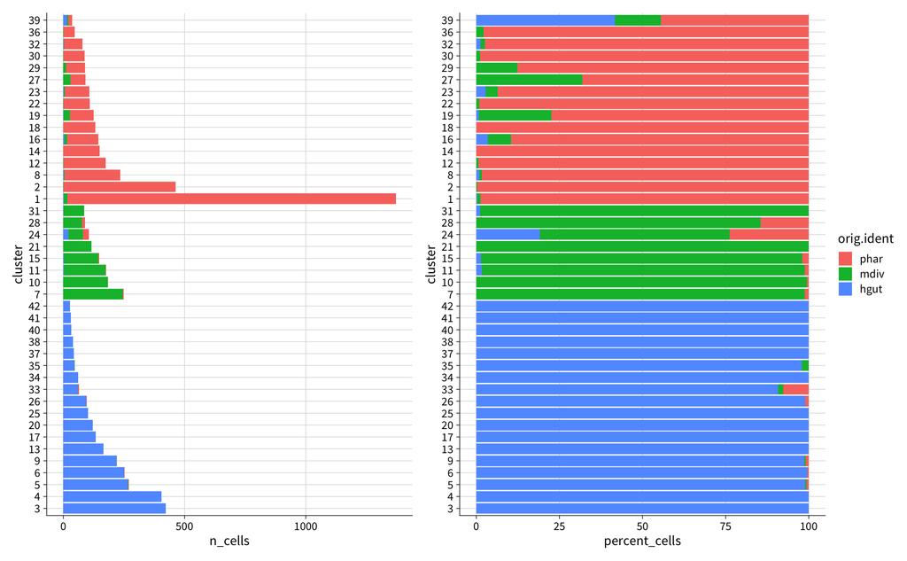

```r
# Arrange clusters by tissue with max cell contribution and use the order as factor levels for plotting
clust_lvls <- bf@meta.data %>%
  group_by(cluster, orig.ident) %>%
  tally() %>%
  ungroup() %>%
  group_by(cluster) %>%
  mutate(percent = n*100/sum(n)) %>%
  ungroup() %>%
  select(-n) %>%
  pivot_wider(names_from = "orig.ident", values_from = "percent") %>%
  mutate(max_tissue = apply(., MARGIN = 1, FUN = which.max)) %>%
  mutate(max_tissue = case_when(max_tissue == 2 ~ "phar",
                                max_tissue == 3 ~ "mdiv",
                                max_tissue == 4 ~ "hgut")) %>%
  arrange(max_tissue) %>%
  mutate(cluster = fct_inorder(cluster)) %>%
  pull(cluster)

# tissue contribution in percent cells
tissue_contrib_pct <- bf@meta.data %>%
  group_by(cluster, orig.ident) %>%
  tally() %>%
  ungroup() %>%
  group_by(cluster) %>%
  mutate(percent_cells = n*100/sum(n)) %>%
  ungroup() %>%
  mutate(cluster = factor(cluster, levels = clust_lvls)) %>%
  ggplot(aes(percent_cells, cluster, fill = orig.ident)) +
  geom_col() +
  theme_half_open_grid()

# tissue contribution in number of cells
tissue_contrib_n <- bf@meta.data %>%
  group_by(cluster, orig.ident) %>%
  tally() %>%
  ungroup() %>%
  mutate(cluster = factor(cluster, levels = clust_lvls)) %>%
  ggplot(aes(n, cluster, fill = orig.ident)) +
  geom_col() +
  labs(x = "n_cells") +
  theme_half_open_grid()

tissue_contrib <- tissue_contrib_n + tissue_contrib_pct + plot_layout(guides = "collect")

ggsave(here(basedir, "results/05b_clustering/tissue-contribution_pct-and-n-cells.pdf"),
       tissue_contrib, width = 9, height = 6.5, units = "in", device = cairo_pdf)

tissue_contrib
```

## 7.5 Correlations between clusters

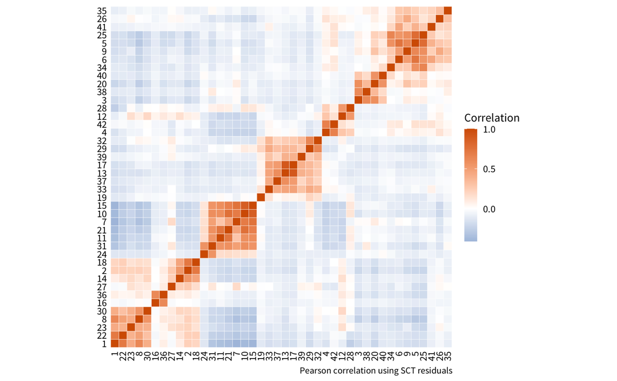

```r
# calculate average gene expression
avg.exp <- AverageExpression(bf,
                             assays = "SCT",
                             slot = "scale.data",
                             features = VariableFeatures(bf),
                             return.seurat = FALSE, verbose = FALSE) %>%
  .[["SCT"]] %>%
  as.data.frame()

# build correlation matrix from expression data
cormat <- cor(avg.exp, method = 'pearson')

# hclust for reordering clusters in plot
dd <- as.dist((1 - cormat))
hc <- hclust(dd, method = 'complete')

# melt
cormat.tidy <- cormat %>%
  as.data.frame() %>%
  rownames_to_column(var = "v1") %>%
  pivot_longer(
    cols = where(is.numeric),
    names_to = "v2",
    values_to = "corr"
  ) %>%
  mutate(v1 = factor(v1, levels = hc$labels[hc$order]),
         v2 = factor(v2, levels = hc$labels[hc$order]))

# plot
p.cormat <- ggplot(data = cormat.tidy,
                   aes(v1, v2, fill = corr, label = round(corr, 2))) +
  geom_tile(colour = "white") +
  scale_fill_gradient2(
    low = pal_okabe[5],
    mid = "White",
    high = pal_okabe[6],
    midpoint = 0,
    name = "Correlation",
    guide = guide_colorbar(barheight = unit(8, "char"))
  ) +
  coord_fixed(ratio = 1) +
  labs(caption = "Pearson correlation using SCT residuals") +
  theme_tileplot(font_size = 10)

ggsave(here(basedir, "results/05b_clustering/cormatrix_avg-exp.pdf"),
       p.cormat, width = 7, height = 6, units = "in", device = cairo_pdf)

p.cormat
```

## 7.6 Hierarchical clustering

```r
cairo_pdf(here(basedir, "results/05b_clustering/hclust.pdf"), width = 6, height = 4, family = .use_font)
plot(hc, cex = 0.75)
dev.off()
```

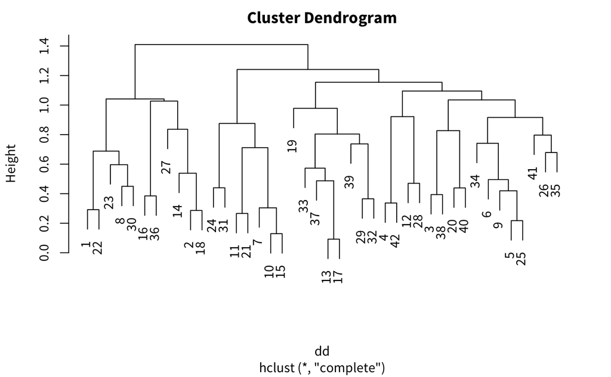

```r
par(family = .use_font)
plot(hc)
```

## 7.7 % mitochondrial genes

```r
# distribution of percent.mt by cluster
percent.mt.vln <- ggplot(data = bf@meta.data %>%
                           mutate(cluster = factor(cluster,
                                                   levels = bf@meta.data %>%
                                                     group_by(cluster) %>%
                                                     summarize(percent.mt_median = median(percent.mt)) %>%
                                                     ungroup() %>%
                                                     arrange(percent.mt_median) %>%
                                                     pull(cluster))),
                         aes(x = percent.mt, y = cluster)) +
  geom_violin(fill = pal_okabe[8]) +
  theme_half_open_grid() +
  theme(aspect.ratio = 1.5)
ggsave(here(basedir, "results/05b_clustering/percent-mt_by-cluster_violin.pdf"),
       percent.mt.vln, device = cairo_pdf, width = 5, height = 8, units = "in")
```

```r
# on umap
percent.mt.umap <- FeaturePlot(bf, features = "percent.mt") +
  theme_half_open_nogrid() +
  theme(aspect.ratio = 1)

ggsave(here(basedir, "results/05b_clustering/percent-mt_umap.pdf"),
       percent.mt.umap, device = cairo_pdf, width = 4, height = 3.5, units = "in")
```

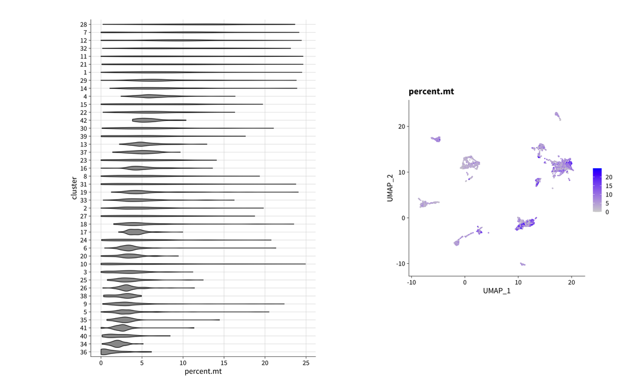

```r
percent.mt.vln + percent.mt.umap + plot_layout(widths = c(2, 1))
```

## 7.8 Number of genes

```r
# distribution of percent.mt by cluster
nfeature.vln <- ggplot(data = bf@meta.data %>%
                           mutate(cluster = factor(cluster,
                                                   levels = bf@meta.data %>%
                                                     group_by(cluster) %>%
                                                     summarize(nfeature_median = median(nFeature_RNA)) %>%
                                                     ungroup() %>%
                                                     arrange(nfeature_median) %>%
                                                     pull(cluster))),
                         aes(x = nFeature_RNA, y = cluster)) +
  geom_violin(fill = pal_okabe[8]) +
  scale_x_log10() +
  annotation_logticks(sides = "b", colour = pal_okabe[8]) +
  theme_half_open_grid() +
  theme(aspect.ratio = 1.5)
ggsave(here(basedir, "results/05b_clustering/n-genes_by-cluster_violin.pdf"),
       nfeature.vln, device = cairo_pdf, width = 5, height = 8, units = "in")
```

```r
# on umap
nfeature.umap <- FeaturePlot(bf, features = "nFeature_RNA", order = TRUE) +
  theme_half_open_nogrid() +
  theme(aspect.ratio = 1)

ggsave(here(basedir, "results/05b_clustering/n-genes_umap.pdf"),
       nfeature.umap, device = cairo_pdf, width = 4, height = 3.5, units = "in")
```

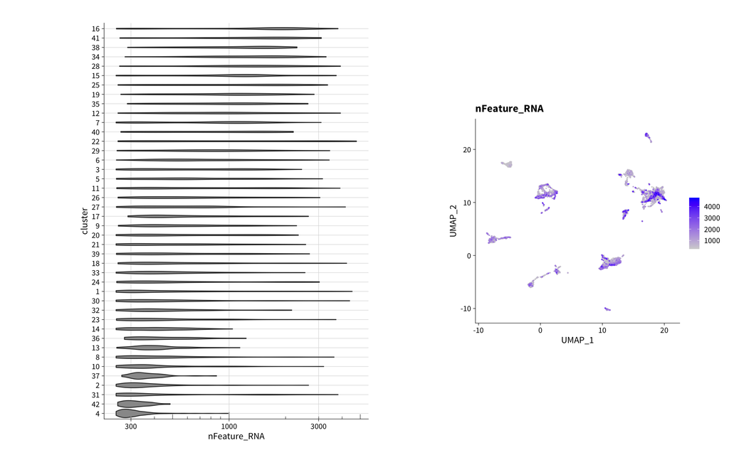

```r
nfeature.vln + nfeature.umap + plot_layout(widths = c(2, 1))
```

# 8 Marker genes

To reduce the numnber of comparisons, we will use only expressed genes, which we here define as genes that have non-zero expression in at least one cluster (according to averaged expression). Technically this may be a superfluous filtering step given that `FindAllMarkers()` by default only tests genes that are expressed in at least 10% of the cells in the cluster.

## 8.1 List of expressed genes

First, we calculate average gene expression. Note that when `return.seurat = FALSE`, the returned values are not log-normalized, so we have to log normalize them.

```r
bf.avg <- AverageExpression(bf, slot = "data", return.seurat = FALSE, verbose = FALSE) %>%
  map(.f = log1p)
```

```r
genes.expressed <- names(which(rowSums(bf.avg$RNA) != 0))
```

## 8.2 Detect

```r
markers.raw <- FindAllMarkers(bf,
                              assay = "RNA",
                              features = genes.expressed,
                              logfc.threshold = 0,
                              return.thresh = 1,
                              base = 2,
                              verbose = FALSE)
```

```r
# save unfiltered output
write_csv(markers.raw, here(basedir, "results/05b_clustering/files/markers_raw-output.csv"))
```

## 8.3 BH correction

Seurat, by default, uses Bonferroni correction. Since that is too conservative, we will use Benjamini-Hochberg corrected p-values instead. There is no option to change the p.adjust method in `FindAllMarkers()`, so we just have to correct them after running `FindAllMarkers()`. In order for us to be able to run BH correction, we need `FindAllMarkers()` to report p-values for all genes, unfiltered by logFC threshold or p value threshol, since it’s not appropriate to run BH correction on a subset of pvalues. For this reason, we have set `logfc.threshold = 0` and `return.thresh = 1` in the `FindAllMarkers()` call above.

```r
# nest
markers <- markers.raw %>%
  group_by(cluster) %>%
  nest() %>%
  ungroup()
```

```r
markers$data <- map(.x = markers$data,
                    .f = function(x) {
                      mutate(x, pval_BH = p.adjust(p = p_val, method = "BH"))
                    })
```

## 8.4 Filter

```r
# filter
markers$data <- markers$data %>%
  map(.f = function(x) {
    filter(x,
           pval_BH < 0.05,
           avg_log2FC > 0.25)
  })
```

```r
write_csv(unnest(markers, cols = data),
          here(basedir, "results/05b_clustering/files/markers_filtered.csv"))
```

## 8.5 Number of markers by cluster

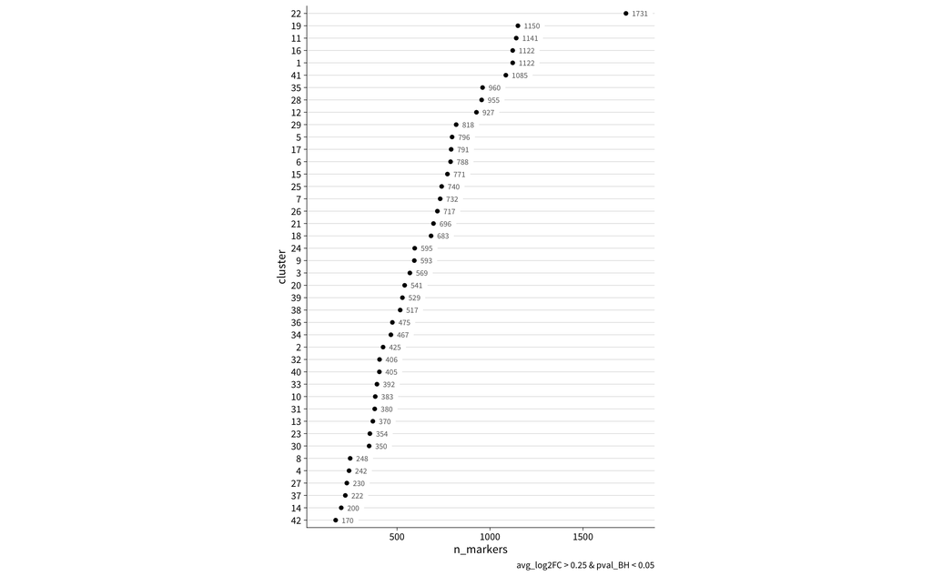

```r
nmarkers.dotplot <- markers %>%
  mutate(n_markers = map_dbl(markers$data, nrow)) %>%
  arrange(n_markers) %>%
  mutate(cluster = fct_inorder(cluster)) %>%
  ggplot(aes(x = n_markers, y = cluster, label = n_markers)) +
  geom_point() +
  geom_label(nudge_x = 20, hjust = 0, size = 8/.pt, color = "grey40", label.size = 0) +
  coord_cartesian(clip = "off", xlim = c(100, 1800)) +
  labs(caption = "avg_log2FC > 0.25 & pval_BH < 0.05") +
  theme_half_open_grid() +
  theme(aspect.ratio = 1.5,
        panel.grid.major.x = element_blank())

ggsave(here(basedir, "results/05b_clustering/n-markers_by-cluster.pdf"),
       nmarkers.dotplot, device = cairo_pdf, width = 5, height = 7.5, units = "in")

nmarkers.dotplot
```

# 9 Save Seurat object

```r
write_rds(bf, here(basedir, "data/05_clustered/bflo_seurat_clustered.rds"), compress = "gz")
```